# Case Stude 02 - Attrition

Edwin Karabidian

11/23/2021

## Executive Summary

DDSAnalytics is an analytics company that specializes in talent management solutions for Fortune 100 companies. The client, Frito Lay company, is seeking the help od DDSAnalytics to analyze and identify causes for employee attrition. Frito Lay would like DDSAnalytics to identify the top three factors that contribute to turnover (backed up by evidence provided by analysis). Frito Lay has provided a dataset for this purpose. This is a dataset of 870 employees’ information with the following data: ID Age DailyRate DistanceFromHome Education EmployeeCount EmployeeNumber EnvironmentSatisfaction HourlyRate JobInvolvement JobLevel JobSatisfaction MonthlyIncome MonthlyRate NumCompaniesWorked PercentSalaryHike PerformanceRating RelationshipSatisfaction StandardHours StockOptionLevel TotalWorkingYears TrainingTimesLastYear WorkLifeBalance YearsAtCompany YearsInCurrentRole YearsSinceLastPromotion YearsWithCurrManager Attrition

GLM (Generalized Linear Model) method was used to rank features by importance, Job Involvement, Job Satisfaction, and Number of companies worked.

The following is the detailed analysis of the task.

```r
options(max.print=999999)
options(tibble.print_max = Inf)
library(tidyverse)
library(caret)
```

```r
library(e1071)
library(ggplot2)
library(corrplot)
library(class)
library(GGally)
library(Metrics)
library(dplyr)
library(plyr)
library(ggthemes)
library(Amelia)
library(mlbench)




## Reading the attrition data provided by Frito Lay
AttritionData = read.csv("C:/Users/Karabidian/Documents/SMU_2/Courses/02_Doing Dtat Science/_Case Study 2/_The Work/CaseStudy2-data.csv", header = TRUE)

## checking to see if there are any NAs in the dataset (there aren't any)
cbind(lapply(lapply(AttritionData, is.na), sum))
```

```
##                          [,1]
## ID                       0
## Age                      0
## Attrition                0
## BusinessTravel           0
## DailyRate                0
## Department               0
## DistanceFromHome         0
## Education                0
## EducationField           0
## EmployeeCount            0
## EmployeeNumber           0
## EnvironmentSatisfaction  0
## Gender                   0
## HourlyRate               0
## JobInvolvement           0
## JobLevel                 0
## JobRole                  0
## JobSatisfaction          0
## MaritalStatus            0
## MonthlyIncome            0
## MonthlyRate              0
## NumCompaniesWorked       0
## Over18                   0
## OverTime                 0
## PercentSalaryHike        0
## PerformanceRating        0
## RelationshipSatisfaction 0
## StandardHours            0
## StockOptionLevel         0
## TotalWorkingYears        0
## TrainingTimesLastYear    0
## WorkLifeBalance          0
## YearsAtCompany           0
## YearsInCurrentRole       0
## YearsSinceLastPromotion  0
## YearsWithCurrManager     0
```

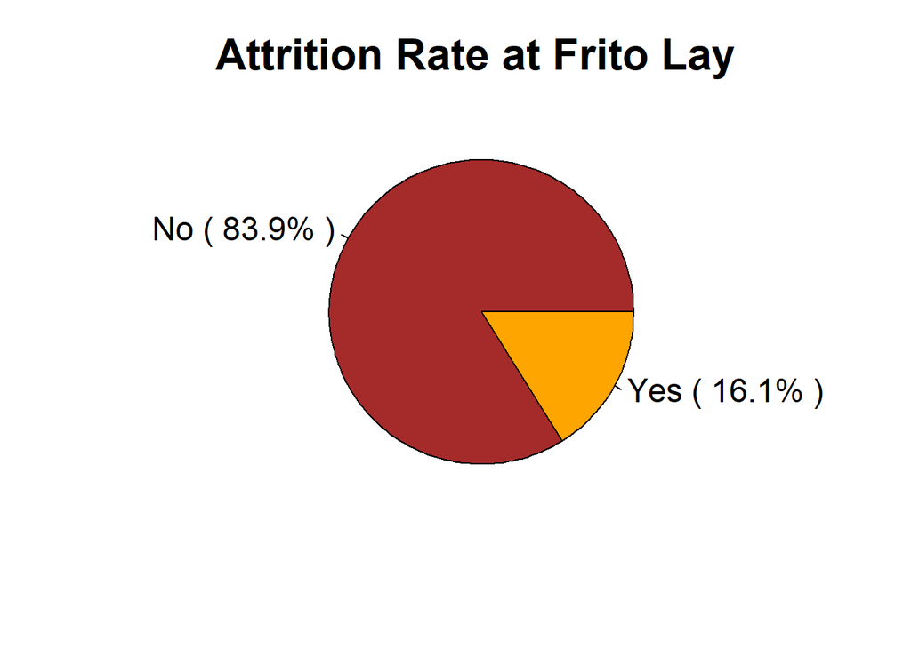

```r
## Plotting Attrition (pie chart)
yess = sum(AttritionData$Attrition == "Yes")
nos = sum(AttritionData$Attrition == "No")

perc_yes = yess/100
perc_no = nos/100

x <-  c(perc_no, perc_yes)
pct <- round(100*x/sum(x),1)

label <-  c("No","Yes")
label <- paste(label, "(",pct)
label <- paste(label, "% )", sep="")

colors=c("brown","orange")
pie(x,labels = label,  col = colors, main = "Attrition Rate at Frito Lay ",  cex.main=2, cex=1.5)
```

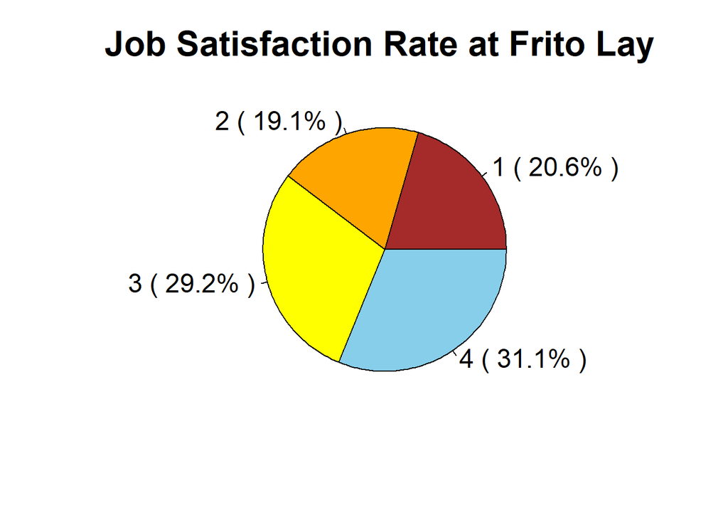

```r
## Plotting Job Satisfaction Rate (pie chart)
one = sum(AttritionData$JobSatisfaction == "1")
two = sum(AttritionData$JobSatisfaction == "2")
three = sum(AttritionData$JobSatisfaction == "3")
four = sum(AttritionData$JobSatisfaction == "4")

perc_one = one/100
perc_two = two/100
perc_three = three/100
perc_four = four/100

x <-  c(perc_one, perc_two, perc_three,perc_four )
pct <- round(100*x/sum(x),1)

label <-  c("1","2","3","4")
label <- paste(label, "(",pct)
label <- paste(label, "% )", sep="")

colors=c("brown","orange", "yellow", "sky blue")
pie(x,labels = label,  col = colors, main = "Job Satisfaction Rate at Frito Lay ",  cex.main=2, cex=1.5)
```

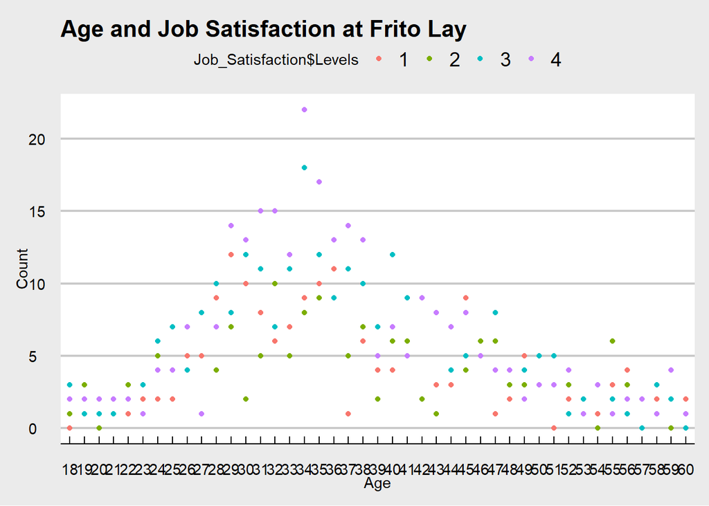

```r
##  Plotting Age vs Job Satisfaction at Frito Lay

table_count<-table(AttritionData$Age, AttritionData$JobSatisfaction)
Job_Satisfaction <- data.frame(table_count)
names(Job_Satisfaction) <- c('Age','Levels','count')
ggplot(Job_Satisfaction, aes(Job_Satisfaction$Age,Job_Satisfaction$count, color=Job_Satisfaction$Levels)) + geom_point() +
  labs(title="Age and Job Satisfaction at Frito Lay",x="Age", y = "Count") +
  theme_economist_white()
```

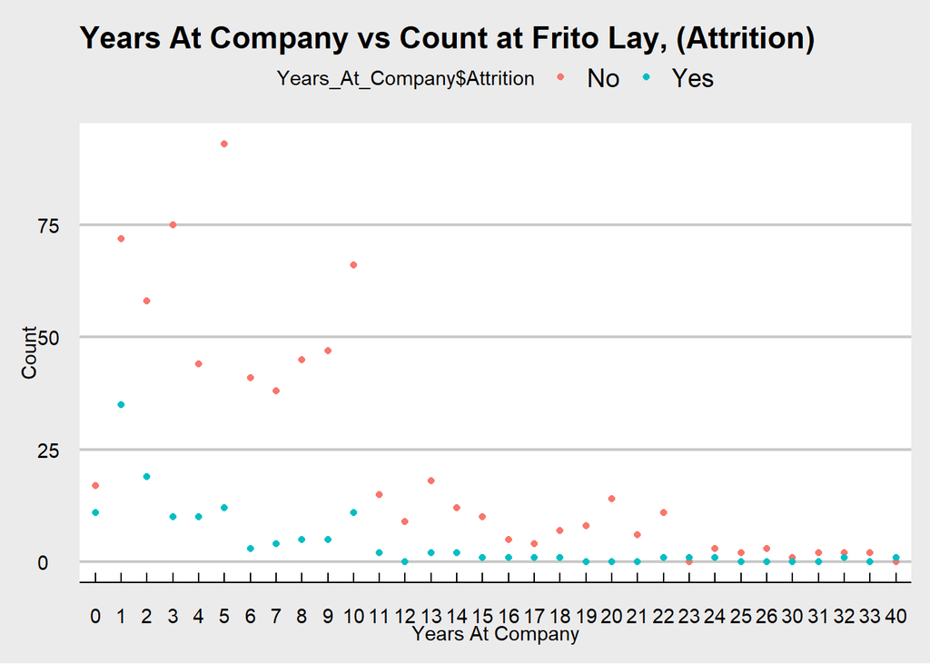

```r
##  Plotting Years At Company vs Count at Frito Lay
table_count<-table(AttritionData$YearsAtCompany, AttritionData$Attrition)
Years_At_Company <- data.frame(table_count)
names(Years_At_Company) <- c('YearsAt','Attrition','count')
ggplot(Years_At_Company, aes(Years_At_Company$YearsAt,Years_At_Company$count, color=Years_At_Company$Attrition)) + geom_point() + labs(title="Years At Company vs Count at Frito Lay, (Attrition)",x="Years At Company", y = "Count") +
  theme_economist_white()
```

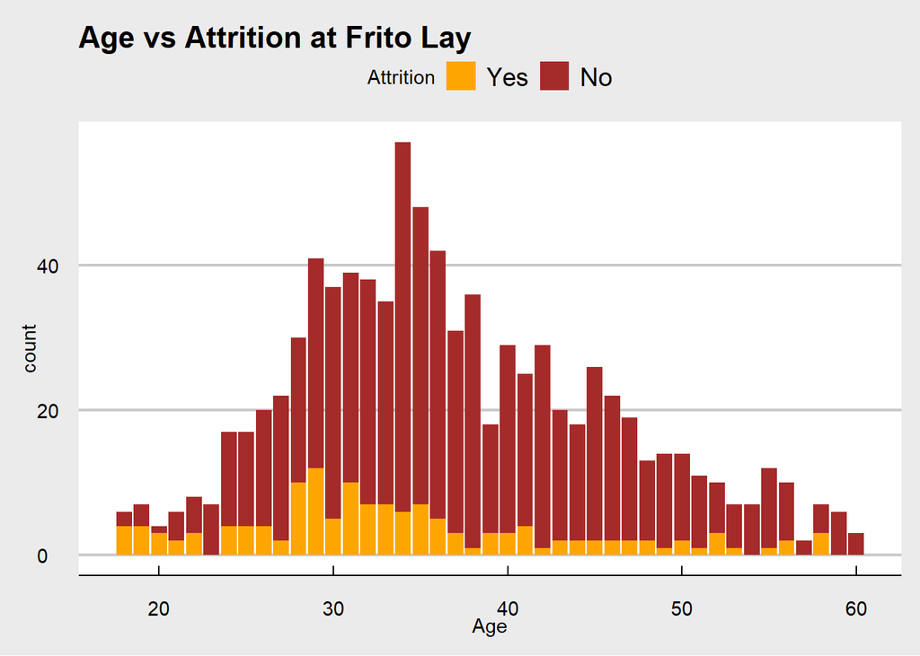

```r
## Plotting Age vs Attrition at Frito Lay

AttritionData %>% ggplot() + geom_bar(aes(Age, fill= Attrition), position = "stack") +
  scale_fill_manual(values = c("Yes" = "orange","No" = "brown")) + ggtitle('Age vs Attrition at Frito Lay') +
  theme_economist_white()
```

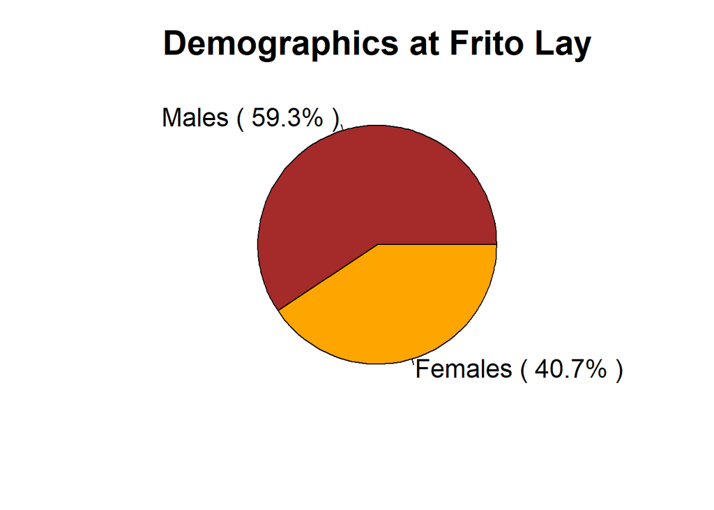

```r
## Plotting demographics (pie chart)
males = sum(AttritionData$Gender == "Male")
females = sum(AttritionData$Gender == "Female")

perc_males = males/100
perc_females = females/100

x <-  c(perc_males, perc_females)
pct <- round(100*x/sum(x),1)

label <-  c("Males","Females")
label <- paste(label, "(",pct)
label <- paste(label, "% )", sep="")

colors=c("brown","orange")
pie(x,labels = label,  col = colors, main = "Demographics at Frito Lay",  cex.main=2, cex=1.5)
```

```r
## Changing "Yes"/"Y" and "No" to 1 and 0

AttritionData$Attrition[AttritionData$Attrition=="Yes"]=1
AttritionData$Attrition[AttritionData$Attrition=="No"]=0
AttritionData$Attrition=as.numeric(AttritionData$Attrition)

AttritionData$Over18[AttritionData$Over18=="Y"]=1
AttritionData$Over18=as.numeric(AttritionData$Over18)

## Changing all the character columns to factors
AttritionData[,c(4,6,8,9,13,17,19,24)]=lapply(AttritionData[,c(4,6,8,9,13,17,19,24)],as.factor)
```

```r
##  Now we choose and plot the top 3 Attrition Predictors
#####  importance of features  ############

set.seed(10)
# load the library
library(mlbench)
library(caret)

# load the dataset
AttritionData = read.csv("C:/Users/Karabidian/Documents/SMU_2/Courses/02_Doing Dtat Science/_Case Study 2/_The Work/CaseStudy2-data.csv", header = TRUE)

AttritionData$Attrition[AttritionData$Attrition=="Yes"]=1
AttritionData$Attrition[AttritionData$Attrition=="No"]=0
AttritionData$Attrition=as.numeric(AttritionData$Attrition)

AttritionData$OverTime[AttritionData$OverTime=="Yes"]=1
AttritionData$OverTime[AttritionData$OverTime=="No"]=0
AttritionData$OverTime=as.numeric(AttritionData$Attrition)

AttritionData$Over18[AttritionData$Over18=="Y"]=1
AttritionData$Over18=as.numeric(AttritionData$Over18)

AttritionData$Over18 <- NULL
AttritionData$StandardHours <- NULL
AttritionData$EmployeeCount <- NULL
AttritionData$OverTime <- NULL

# write.csv(AttritionData,"C:/Users/Karabidian/Documents/SMU_2/Courses/02_Doing Dtat Science/_Case Study 2/_The Work/out.csv", row.names = FALSE)

# prepare training scheme
control <- trainControl(method="repeatedcv", number=33, repeats=3)

# train the model
model <- train(Attrition~., data=AttritionData, method="glm", preProcess="scale", trControl=control)
# estimate variable importance
importance <- varImp(model, scale=FALSE)

# summarize importance
print(importance)
```

```
## glm variable importance
##
##   only 20 most important variables shown (out of 45)
##
##                                 Overall
## JobInvolvement                    5.342
## JobSatisfaction                   4.089
## NumCompaniesWorked                3.995
## DistanceFromHome                  3.415
## MaritalStatusSingle               3.247
## YearsSinceLastPromotion           3.154
## WorkLifeBalance                   2.628
## BusinessTravelTravel_Frequently   2.609
## TrainingTimesLastYear             2.482
## TotalWorkingYears                 2.208
## RelationshipSatisfaction          2.199
## EnvironmentSatisfaction           2.063
## `JobRoleSales Representative`     2.002
## EducationFieldMedical             1.833
## `EducationFieldLife Sciences`     1.830
## YearsInCurrentRole                1.696
## EducationFieldMarketing           1.679
## YearsWithCurrManager              1.578
## BusinessTravelTravel_Rarely       1.555
## EducationFieldOther               1.518
```

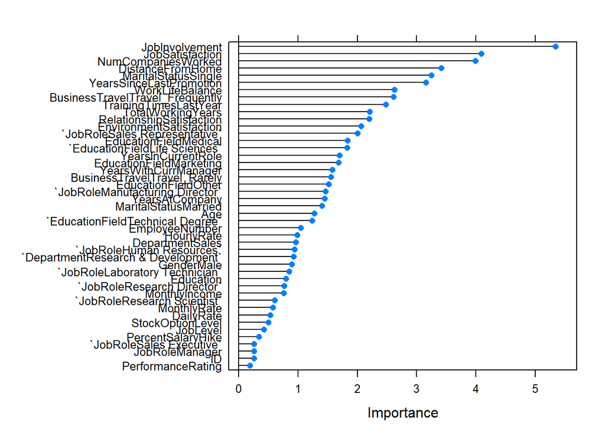

```r
# plot importance
plot(importance)
```

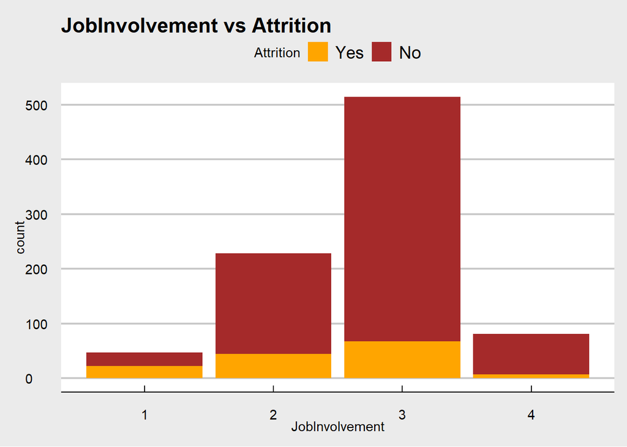

```r
##  Plotting top three factors that contribute to Attrition

AttritionData = read.csv("C:/Users/Karabidian/Documents/SMU_2/Courses/02_Doing Dtat Science/_Case Study 2/_The Work/CaseStudy2-data.csv", header = TRUE)


AttritionData %>% ggplot() + geom_bar(aes(JobInvolvement, fill= Attrition), position = "stack") +   scale_fill_manual(values = c("Yes" = "orange","No" = "brown")) + ggtitle('JobInvolvement vs Attrition')+theme_economist_white()
```